# The Killer of the Century

2026-03-03

## Introduction

There are lots of factors contributing to climate change, a problem that if left unresolved could lead to the destruction of the world. This would decrease access to resources for the ever expanding population and increase the death rate which is already affected by many conditions. Despite advances in medicine, there is still a prominence in death by chronic disease. These issues may seem separate; however, there is a culprit influencing both problems.

The criminal is meat, specifically the normalization of current consumption amounts. Not only is meat crippling the healthy hearts of people, it is contributing to the crippling of the environment and world as we know it.

## The Origin Story

The increase in population has only increased the demand for meat, encouraging industry meat production as the main source of meat.

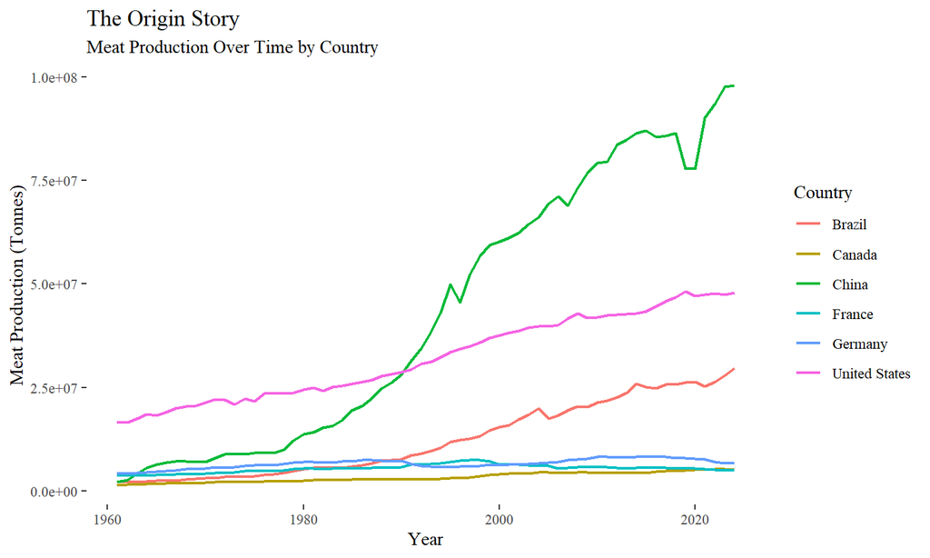

## The Origin Story

Early humans did not have to rely on energy-consumptive processes like transporting animals and feed, deforesting, water usage, and packaging in order to eat meat. The spiked demand for meat has also spurred breeding of livestock, which produce methane as a part of their digestive process. So, increased demand for meat has increased the population of animals that produce methane as a byproduct of digestion.

## Meat Production and Emmissions

This suggests that there’s a correlation between meat production and greenhouse gas emissions from food systems, reinforcing the environmental toll of meat.

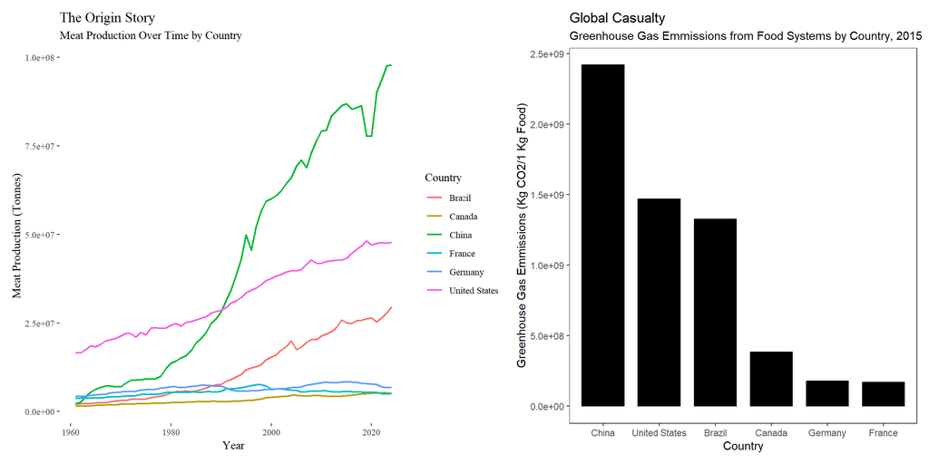

## Meat Production and Emissions

These trends harbour a safe haven for a killer. Our World In Data claims that food production alone is responsible for a quarter of global emissions. Meat production and consumption will play a large role in killing the world if greenhouse gas emissions are not reduced soon. This can only happen if collective effort worldwide occurs with everyone committing to changing their practices. An easy way anyone can participate is to stop nurturing the culprit. Not everyone has time to reach out to their representatives or keep up with ever-changing policies. However, limiting meat consumption will lessen the demand for meat which could promote the presence of small, local meat farmers that typically have less emissions-heavy practices and incentivize food corporations to invest more in other types of food production. In fact, even a 50% decrease in meat consumption would reduce the carbon footprint associated with food systems by 31% according to the University of Vermont. Even if halving meat consumption seems daunting, simply limiting or avoiding beef can reduce the carbon footprint related to diet.

## Beef/Buffalo Consumption

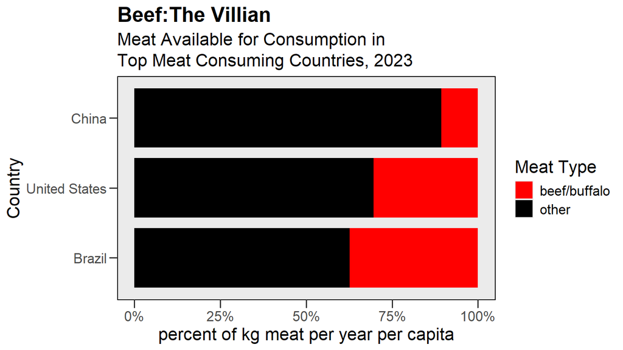

## Beef/Buffalo Consumption

The USDA notes that 3.3% of all of the United States’ emissions were due to cattle farming, higher than any other single food group, meaning even reductions in beef consumption are meaningful in restraining the power of meat as a global killer. Further, a study performed by Stanford found that replacing beef with chicken or plant-based proteins could reduce the average American’s dietary carbon footprint by 31% and improve nutrition quality by up to 10%. Implementing these types of diets or simply being more conscious of beef consumption could significantly reduce greenhouse gas emissions from meat in the countries with the highest meat consumption. While many factors that contribute to climate change seem complex, meat consumption has a clear path of opportunity to curb this problem and start building a more sustainable world for everyone. Don’t let the killer stay at large.

## Meat and Health

Meat is not only constricting us on the global scale, but it is ruining lives, as well. Prehistorically, meat was an excellent calorie-dense source of protein for early humans. It still can be, but the difference is now we have much more regular access to meat, especially fattier parts of meat. Early humans could only eat meat as much as they catch it, and, today, most people consume meat, often fatty and highly processed, on a daily basis. Now, a once dietary tool for humans is being used as a tool of death. Our bodies have not developed a tolerance to these increased levels of meat consumption.

## Meat and Health

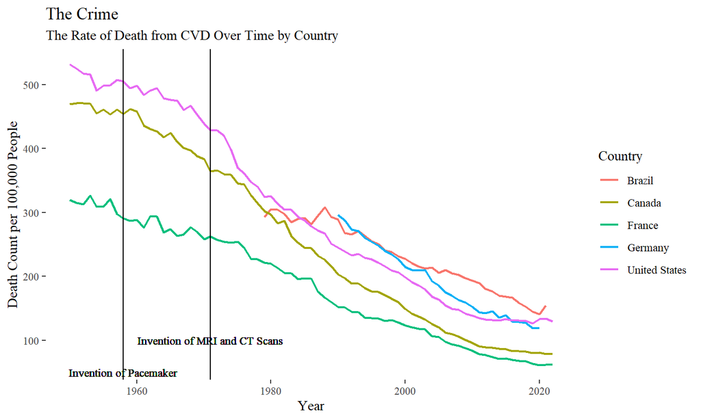

## Meat and Health

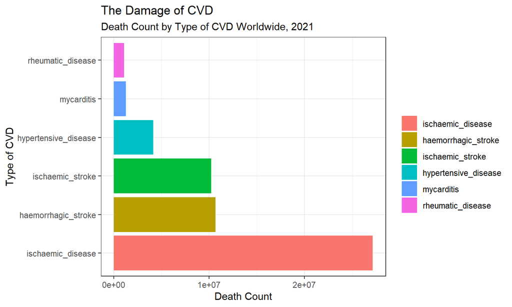

In 2021, the type of CVD that had the greatest death count worldwide was ischaemic heart disease.

## Closing the Case

A better future can be achieved by just limiting meat consumption, especially red meat consumption. Food systems are a large contributor to global emissions. Future generations depend on our actions today: if climate trends persist, our children and grandchildren will have to navigate a world very different from the one we experienced. Ecosystems will be disrupted, access to resources will be scarce, and, eventually, death tolls would spike. The Earth could lose its ability to support humanity or any forms of life. Additionally, we create the culture today that will have great influence on future generations, including their diet culture. The devastation of CVD could be significantly limited if overconsumption of meat was less normalized. There’s potential to help save the world and save heart health by reducing meat consumption. Who will be a hero?

## Resources

[Meat Production,](https://ourworldindata.org/grapher/meat-production-tonnes.csv?v=1&csvType=full&useColumnShortNames=true) [Meat Consumption and GDP,](https://ourworldindata.org/grapher/meat-consumption-vs-gdp-per-capita.csv?v=1&csvType=full&useColumnShortNames=true) [Meat Consumption by Type,](https://ourworldindata.org/grapher/per-capita-meat-consumption-by-type-kilograms-per-year.csv?v=1&csvType=full&useColumnShortNames=true) [Carbon Emissions from Food Systems,](https://ourworldindata.org/grapher/emissions-from-food.csv?v=1&csvType=full&useColumnShortNames=true) [Death rate from cvd,](https://ourworldindata.org/grapher/cardiovascular-disease-death-rate-who-mdb.csv?v=1&csvType=full&useColumnShortNames=true) [University of Vermont Article,](https://www.uvm.edu/gund/news/cut-global-emissions-replace-meat-and-milk-plant-based-alternatives) [AHS Ischaemic Disease,](https://www.heart.org/en/health-topics/heart-attack/about-heart-attacks/silent-ischemia-and-ischemic-heart-disease) [AHD Saturated Fat,](https://www.heart.org/en/healthy-living/healthy-eating/eat-smart/fats/saturated-fats) [USDA Beef Emmissions,](https://www.ars.usda.gov/news-events/news/research-news/2019/study-clarifies-us-beefs-resource-use-and-greenhouse-gas-emissions/) [Standford Study](https://woods.stanford.edu/news/meats-environmental-impact)